# Project: Investigate a Dataset - [TMDb movie data]

Welcome to the Investigate a Dataset project!

- Introduction
- Data Wrangling
- Exploratory Data Analysis
- Conclusions

#

# Introduction About This Dataset

This data set contains information about "10,000" movies collected from The Movie Database (TMDb), including user ratings and revenue. [Dataset link](https://d17h27t6h515a5.cloudfront.net/topher/2017/October/59dd1c4c_tmdb-movies/tmdb-movies.csv)

**dataset has the following features:-**

- imdb_id - A unique identifier for each movie.
- cast - The name of lead and supporting actors.
  - director - The name of Director
  - budget - The budget in which the movie was made.
  - budget_adj - show the budget and revenue of the associated movie in terms of 2010 dollars,
  - genres - The genre of the movie, Action, Comedy ,Thriller etc.
  - homepage - A link to the homepage of the movie.
  - keywords - The keywords or tags related to the movie.
  - original_title - The title of the movie before translation or adaptation.
  - overview - A brief description of the movie.
  - popularity - A numeric quantity specifying the movie popularity.
  - production_companies - The production house of the movie.
  - release_date - The date on which it was released.
  - release_year - The year on which it was released.
  - revenue - The worldwide revenue generated by the movie.
  - revenue_adj-show the revenue of the associated movie in terms of 2010 dollars
  - runtime - The running time of the movie in minutes.
  - tagline - Movie's tagline.
  - vote_average - average ratings the movie recieved.
  - vote_count - the count of votes recieved

### Questions that will be answered:

- Which movie have high popularity over this years ?
- Is there a relation between budget and revenue ?
- What kinds of properties are associated with movies that have high revenues ?
- Which Genres have high popularity in specific year or period time ?

### Data Wrangling

```python
!pip install -U pandas==0.25.0.
```

```python
#load data and import necessary libraries
import pandas as pd
import matplotlib.pyplot as plt
df=pd.read_csv("https://d17h27t6h515a5.cloudfront.net/topher/2017/October/59dd1c4c_tmdb-movies/tmdb-movies.csv")
```

```python
df["genres"].head(2)
```

```
0    Action|Adventure|Science Fiction|Thriller
1    Action|Adventure|Science Fiction|Thriller
Name: genres, dtype: object
```

```python
#Find the missing values
df.isna().sum()
```

```
id                         0
imdb_id                   10
popularity                 0
budget                     0
revenue                    0
original_title             0
cast                      76
homepage                7930
director                  44
tagline                 2824
keywords                1493
overview                   4
runtime                    0
genres                    23
production_companies    1030
release_date               0
vote_count                 0
vote_average               0
release_year               0
budget_adj                 0
revenue_adj                0
dtype: int64
```

```python
#Delete columns that I don't need to answer my questions
remove_columns_list=["imdb_id" ,"id","cast","homepage","director","keywords" ,"overview" , "tagline"]
df.drop(remove_columns_list , axis=1 , inplace=True)
```

```python
df.columns
```

```
Index(['popularity', 'budget', 'revenue', 'original_title', 'runtime',
       'genres', 'production_companies', 'release_date', 'vote_count',
       'vote_average', 'release_year', 'budget_adj', 'revenue_adj'],
      dtype='object')
```

```python
#Delete rows that contain a missing value
df.dropna(inplace=True)
```

```python
#Ensure that there is no missing value
df.isna().sum()
```

```
popularity              0
budget                  0
revenue                 0
original_title          0
runtime                 0
genres                  0
production_companies    0
release_date            0
vote_count              0
vote_average            0
release_year            0
budget_adj              0
revenue_adj             0
dtype: int64
```

```python
#Ensure that there are no duplicate values
print(sum(df.duplicated()))
df[df.duplicated()==True]
```

```
1
```

|  | popularity | budget | revenue | original_title | runtime | genres | production_companies | release_date | vote_count | vote_average | release_year | budget_adj | revenue_adj |
| --- | --- | --- | --- | --- | --- | --- | --- | --- | --- | --- | --- | --- | --- |
| 2090 | 0.59643 | 30000000 | 967000 | TEKKEN | 92 | Crime\|Drama\|Action\|Thriller\|Science Fiction | Namco\|Light Song Films | 3/20/10 | 110 | 5.0 | 2010 | 30000000.0 | 967000.0 |

```python
#We will make a change "release_date" type
df.info()
```

```
<class 'pandas.core.frame.DataFrame'>
Int64Index: 9827 entries, 0 to 10865
Data columns (total 13 columns):
popularity              9827 non-null float64
budget                  9827 non-null int64
revenue                 9827 non-null int64
original_title          9827 non-null object
runtime                 9827 non-null int64
genres                  9827 non-null object
production_companies    9827 non-null object
release_date            9827 non-null object
vote_count              9827 non-null int64
vote_average            9827 non-null float64
release_year            9827 non-null int64
budget_adj              9827 non-null float64
revenue_adj             9827 non-null float64
dtypes: float64(4), int64(5), object(4)
memory usage: 1.0+ MB
```

```python
df["release_date"]= pd.to_datetime(df["release_date"])
```

```python
#Ensure that the change has occurred
df.info()
```

```
<class 'pandas.core.frame.DataFrame'>
Int64Index: 9827 entries, 0 to 10865
Data columns (total 13 columns):
popularity              9827 non-null float64
budget                  9827 non-null int64
revenue                 9827 non-null int64
original_title          9827 non-null object
runtime                 9827 non-null int64
genres                  9827 non-null object
production_companies    9827 non-null object
release_date            9827 non-null datetime64[ns]
vote_count              9827 non-null int64
vote_average            9827 non-null float64
release_year            9827 non-null int64
budget_adj              9827 non-null float64
revenue_adj             9827 non-null float64
dtypes: datetime64[ns](1), float64(4), int64(5), object(3)
memory usage: 1.0+ MB
```

```python
df.describe()
```

|  | popularity | budget | revenue | runtime | vote_count | vote_average | release_year | budget_adj | revenue_adj |
| --- | --- | --- | --- | --- | --- | --- | --- | --- | --- |
| count | 9827.000000 | 9.827000e+03 | 9.827000e+03 | 9827.000000 | 9827.000000 | 9827.000000 | 9827.000000 | 9.827000e+03 | 9.827000e+03 |
| mean | 0.692004 | 1.609461e+07 | 4.398487e+07 | 102.673858 | 238.165157 | 5.967874 | 2000.904142 | 1.931318e+07 | 5.673501e+07 |
| std | 1.034731 | 3.214198e+07 | 1.222895e+08 | 28.201627 | 601.519753 | 0.914524 | 13.032228 | 3.559418e+07 | 1.510850e+08 |
| min | 0.000188 | 0.000000e+00 | 0.000000e+00 | 0.000000 | 10.000000 | 1.500000 | 1960.000000 | 0.000000e+00 | 0.000000e+00 |
| 25% | 0.230927 | 0.000000e+00 | 0.000000e+00 | 90.000000 | 18.000000 | 5.400000 | 1994.000000 | 0.000000e+00 | 0.000000e+00 |
| 50% | 0.417317 | 1.250000e+05 | 0.000000e+00 | 100.000000 | 45.000000 | 6.000000 | 2005.000000 | 2.025573e+05 | 0.000000e+00 |
| 75% | 0.773583 | 1.900000e+07 | 3.052564e+07 | 112.000000 | 172.000000 | 6.600000 | 2011.000000 | 2.432644e+07 | 4.248161e+07 |
| max | 32.985763 | 4.250000e+08 | 2.781506e+09 | 877.000000 | 9767.000000 | 8.700000 | 2015.000000 | 4.250000e+08 | 2.827124e+09 |

**We note here that there is a running time of the movie equal to zero, which is illogical**

```python
df[df["runtime"]==0]
```

|  | popularity | budget | revenue | original_title | runtime | genres | production_companies | release_date | vote_count | vote_average | release_year | budget_adj | revenue_adj |
| --- | --- | --- | --- | --- | --- | --- | --- | --- | --- | --- | --- | --- | --- |
| 92 | 1.876037 | 0 | 0 | Mythica: The Necromancer | 0 | Fantasy\|Action\|Adventure | Arrowstorm Entertainment\|Camera 40 Productions... | 2015-12-19 | 11 | 5.4 | 2015 | 0.000000e+00 | 0.0 |
| 334 | 0.357654 | 0 | 0 | Ronaldo | 0 | Documentary | On The Corner Films\|We Came, We Saw, We Conque... | 2015-11-09 | 80 | 6.5 | 2015 | 0.000000e+00 | 0.0 |
| 445 | 0.218528 | 0 | 0 | The Exorcism of Molly Hartley | 0 | Horror | WT Canada Productions | 2015-10-09 | 52 | 5.0 | 2015 | 0.000000e+00 | 0.0 |
| 486 | 0.176744 | 0 | 0 | If There Be Thorns | 0 | TV Movie\|Drama | A+E Studios\|Jane Startz Productions | 2015-04-05 | 11 | 5.4 | 2015 | 0.000000e+00 | 0.0 |
| 1289 | 0.037459 | 3250000 | 0 | Treehouse | 0 | Thriller\|Horror\|Mystery | Tiberius Film | 2014-10-20 | 16 | 3.4 | 2014 | 2.993546e+06 | 0.0 |
| 1293 | 0.036904 | 0 | 0 | Tim Maia | 0 | Documentary\|Drama\|Music | Globo Filmes | 2014-10-30 | 14 | 6.0 | 2014 | 0.000000e+00 | 0.0 |
| 3329 | 0.082898 | 0 | 0 | Grande, grosso e Verdone | 0 | Family | Filmauro | 2008-03-07 | 35 | 5.3 | 2008 | 0.000000e+00 | 0.0 |
| 3857 | 0.095583 | 0 | 0 | Cell 213 | 0 | Horror | Access Motion Pictures | 2011-06-10 | 13 | 5.2 | 2011 | 0.000000e+00 | 0.0 |
| 4944 | 0.026459 | 0 | 0 | How to Fall in Love | 0 | Comedy\|Romance\|TV Movie | Annuit Coeptis Entertainment Inc.\|Annuit Coept... | 2012-07-21 | 11 | 4.7 | 2012 | 0.000000e+00 | 0.0 |
| 5695 | 0.417739 | 0 | 0 | Skinwalker Ranch | 0 | Thriller\|Horror\|Science Fiction | DeepStudios | 2013-10-30 | 27 | 4.3 | 2013 | 0.000000e+00 | 0.0 |
| 5920 | 0.165765 | 0 | 0 | The Food Guide to Love | 0 | Romance\|Comedy | Haut et Court\|Parallel Film Productions\|Fox In... | 2013-12-18 | 12 | 5.6 | 2013 | 0.000000e+00 | 0.0 |
| 5938 | 0.147188 | 0 | 0 | Go Goa Gone | 0 | Comedy\|Horror | Eros International | 2013-05-10 | 16 | 5.3 | 2013 | 0.000000e+00 | 0.0 |
| 6934 | 0.071872 | 0 | 0 | Jean-Philippe | 0 | Comedy | Fidélité Productions\|StudioCanal\|TF1 Films P... | 2006-04-05 | 26 | 5.6 | 2006 | 0.000000e+00 | 0.0 |

```python
#So I searched for the running time of these movies and modified the values

index=[92 , 334 ,445 ,486 ,1289 ,1293 ,3329 ,3857 ,4944 ,5695 , 5920 , 5938 , 6934]
value=[93 ,92 ,96,100 ,100 , 140 ,135 ,109 ,84 ,86 ,91 ,112 , 90]
my_list=list(zip(index , value))
for ind , val in my_list:
    df.loc[ind , 'runtime']=val
```

```python
df[df["runtime"]==0]
```

|  | popularity | budget | revenue | original_title | runtime | genres | production_companies | release_date | vote_count | vote_average | release_year | budget_adj | revenue_adj |
| --- | --- | --- | --- | --- | --- | --- | --- | --- | --- | --- | --- | --- | --- |

```python
df[df["revenue"]==0]
```

|  | popularity | budget | revenue | original_title | runtime | genres | production_companies | release_date | vote_count | vote_average | release_year | budget_adj | revenue_adj |
| --- | --- | --- | --- | --- | --- | --- | --- | --- | --- | --- | --- | --- | --- |
| 48 | 2.932340 | 30000000 | 0 | Wild Card | 92 | Thriller\|Crime\|Drama | Current Entertainment\|Lionsgate\|Sierra / Affin... | 2015-01-14 | 481 | 5.3 | 2015 | 2.759999e+07 | 0.0 |
| 67 | 2.331636 | 20000000 | 0 | Survivor | 96 | Crime\|Thriller\|Action | Nu Image Films\|Winkler Films\|Millennium Films\|... | 2015-05-21 | 280 | 5.4 | 2015 | 1.839999e+07 | 0.0 |
| 74 | 2.165433 | 0 | 0 | Mythica: The Darkspore | 108 | Action\|Adventure\|Fantasy | Arrowstorm Entertainment | 2015-06-24 | 27 | 5.1 | 2015 | 0.000000e+00 | 0.0 |
| 75 | 2.141506 | 0 | 0 | Me and Earl and the Dying Girl | 105 | Comedy\|Drama | Indian Paintbrush | 2015-06-12 | 569 | 7.7 | 2015 | 0.000000e+00 | 0.0 |
| 92 | 1.876037 | 0 | 0 | Mythica: The Necromancer | 93 | Fantasy\|Action\|Adventure | Arrowstorm Entertainment\|Camera 40 Productions... | 2015-12-19 | 11 | 5.4 | 2015 | 0.000000e+00 | 0.0 |
| 93 | 1.872696 | 10000000 | 0 | Vice | 96 | Thriller\|Science Fiction\|Action\|Adventure | Grindstone Entertainment Group\|K5 Internationa... | 2015-01-16 | 181 | 4.1 | 2015 | 9.199996e+06 | 0.0 |
| 100 | 1.724712 | 0 | 0 | Frozen Fever | 8 | Adventure\|Animation\|Family | Walt Disney Pictures\|Walt Disney Animation Stu... | 2015-03-09 | 475 | 7.0 | 2015 | 0.000000e+00 | 0.0 |
| 101 | 1.661789 | 0 | 0 | High-Rise | 119 | Action\|Drama\|Science Fiction | Ingenious Media\|HanWay Films\|Scope Pictures\|Re... | 2015-09-26 | 161 | 5.4 | 2015 | 0.000000e+00 | 0.0 |
| 103 | 1.646664 | 0 | 0 | Spooks: The Greater Good | 104 | Thriller\|Action | BBC Films\|Isle of Man Film\|Shine Pictures\|Kudo... | 2015-04-11 | 114 | 5.6 | 2015 | 0.000000e+00 | 0.0 |
| 116 | 1.380320 | 0 | 0 | The Scorpion King: The Lost Throne | 105 | Action\|Fantasy\|Adventure | Universal Pictures | 2015-01-09 | 22 | 4.5 | 2015 | 0.000000e+00 | 0.0 |
| 122 | 1.342839 | 0 | 0 | Everly | 90 | Thriller\|Action | Crime Scene Pictures\|Radius-TWC\|Anonymous Cont... | 2015-01-23 | 169 | 5.1 | 2015 | 0.000000e+00 | 0.0 |
| 133 | 1.251681 | 11000000 | 0 | Louder Than Bombs | 109 | Drama | Motlys\|Arte France CinÃ©ma\|Animal Kingdom | 2015-05-18 | 43 | 6.3 | 2015 | 1.012000e+07 | 0.0 |
| 140 | 1.144808 | 0 | 0 | Dragonheart 3: The Sorcerer's Curse | 97 | Action\|Adventure\|Fantasy | Raffaella Productions | 2015-02-24 | 59 | 4.5 | 2015 | 0.000000e+00 | 0.0 |
| 143 | 1.128081 | 0 | 0 | Brothers of the Wind | 98 | Adventure\|Drama\|Family | Terra Mater Factual Studios | 2015-12-24 | 11 | 7.5 | 2015 | 0.000000e+00 | 0.0 |
| 145 | 1.073349 | 1800000 | 0 | Bone Tomahawk | 132 | Horror\|Western\|Adventure\|Drama | Caliber Media Company\|The Fyzz Facility\|Realbu... | 2015-10-23 | 220 | 6.3 | 2015 | 1.655999e+06 | 0.0 |
| 147 | 1.063055 | 0 | 0 | Pawn Sacrifice | 114 | Drama | Material Pictures\|MICA Entertainment\|PalmStar ... | 2015-09-16 | 148 | 6.6 | 2015 | 0.000000e+00 | 0.0 |
| 149 | 1.041922 | 20000000 | 0 | Momentum | 96 | Thriller\|Action | Thaba Media\|Azari Media | 2015-08-01 | 100 | 5.8 | 2015 | 1.839999e+07 | 0.0 |
| 151 | 1.036825 | 0 | 0 | Pay the Ghost | 94 | Horror\|Thriller | Voltage Films\|Midnight Kitchen Productions | 2015-09-16 | 114 | 5.3 | 2015 | 0.000000e+00 | 0.0 |
| 152 | 1.027620 | 0 | 0 | The Voices | 101 | Horror\|Thriller\|Comedy\|Crime | Studio Babelsberg\|Mandalay Vision\|1984 Private... | 2015-02-06 | 371 | 6.0 | 2015 | 0.000000e+00 | 0.0 |
| 154 | 1.008474 | 12000000 | 0 | Il racconto dei racconti | 125 | Romance\|Fantasy\|Horror | HanWay Films\|Rai Cinema\|Le Pacte\|Fonds Eurimag... | 2015-05-14 | 211 | 5.7 | 2015 | 1.104000e+07 | 0.0 |
| 156 | 0.973316 | 15000000 | 0 | Queen of the Desert | 128 | Drama\|History | Benaroya Pictures\|H Films\|Raslan Company of Am... | 2015-09-03 | 30 | 6.0 | 2015 | 1.379999e+07 | 0.0 |
| 158 | 0.953647 | 0 | 0 | Miss You Already | 112 | Comedy\|Drama\|Romance | S Films\|New Sparta Films | 2015-09-12 | 139 | 7.2 | 2015 | 0.000000e+00 | 0.0 |
| 159 | 0.953046 | 630019 | 0 | Kung Fury | 31 | Action\|Comedy\|Science Fiction\|Fantasy | Laser Unicorns | 2015-05-28 | 487 | 7.7 | 2015 | 5.796172e+05 | 0.0 |
| 164 | 0.917040 | 0 | 0 | Kidnapping Mr. Heineken | 95 | Drama\|Action\|Crime\|Thriller | Umedia\|Informant Europe SPRL\|European Film Com... | 2015-03-12 | 131 | 5.8 | 2015 | 0.000000e+00 | 0.0 |
| 165 | 0.913085 | 60000000 | 0 | The Ridiculous 6 | 119 | Comedy\|Western | Happy Madison Productions | 2015-12-11 | 252 | 4.8 | 2015 | 5.519998e+07 | 0.0 |
| 166 | 0.906860 | 0 | 0 | Kill Me Three Times | 90 | Comedy\|Thriller | Parabolic Pictures\|Stable Way Entertainment\|Ca... | 2015-04-10 | 96 | 5.1 | 2015 | 0.000000e+00 | 0.0 |
| 169 | 0.894477 | 0 | 0 | 45 Years | 95 | Drama | The Bureau | 2015-08-28 | 167 | 6.0 | 2015 | 0.000000e+00 | 0.0 |
| 174 | 0.861179 | 0 | 0 | Jenny's Wedding | 94 | Comedy\|Drama | MM Productions\|Merced Media Partners\|PalmStar ... | 2015-07-31 | 92 | 5.2 | 2015 | 0.000000e+00 | 0.0 |
| 175 | 0.848748 | 0 | 0 | Descendants | 112 | Music\|Action\|Adventure\|Comedy\|Family | Walt Disney Television | 2015-07-31 | 262 | 6.7 | 2015 | 0.000000e+00 | 0.0 |
| 176 | 0.843174 | 0 | 0 | Tumbledown | 105 | Music\|Romance\|Comedy | Echo Films\|Bron Studios\|Hahnscape | 2015-04-18 | 22 | 6.6 | 2015 | 0.000000e+00 | 0.0 |
| ... | ... | ... | ... | ... | ... | ... | ... | ... | ... | ... | ... | ... | ... |
| 10832 | 0.358161 | 4800000 | 0 | Arabesque | 105 | Action\|Adventure\|Thriller | Universal Pictures\|Stanley Donen Films | 2066-05-05 | 14 | 5.6 | 1966 | 3.224647e+07 | 0.0 |
| 10833 | 0.737730 | 0 | 0 | How to Steal a Million | 123 | Comedy\|Crime\|Romance | World Wide Productions | 2066-07-13 | 67 | 7.3 | 1966 | 0.000000e+00 | 0.0 |
| 10834 | 0.310688 | 0 | 0 | Return of the Seven | 95 | Action\|Western | C.B. Films S.A.\|The Mirisch Production Company | 2066-10-19 | 14 | 5.1 | 1966 | 0.000000e+00 | 0.0 |
| 10836 | 0.239435 | 0 | 0 | Walk Don't Run | 114 | Comedy\|Romance | Columbia Pictures Corporation | 2066-01-01 | 11 | 5.8 | 1966 | 0.000000e+00 | 0.0 |
| 10837 | 0.291704 | 0 | 0 | The Blue Max | 156 | War\|Action\|Adventure\|Drama | Twentieth Century Fox Film Corporation | 2066-06-21 | 12 | 5.5 | 1966 | 0.000000e+00 | 0.0 |
| 10838 | 0.151845 | 0 | 0 | The Professionals | 117 | Action\|Adventure\|Western | Columbia Pictures | 2066-11-01 | 21 | 6.0 | 1966 | 0.000000e+00 | 0.0 |
| 10839 | 0.276133 | 0 | 0 | It's the Great Pumpkin, Charlie Brown | 25 | Family\|Animation | Warner Bros. Home Video | 2066-10-27 | 49 | 7.2 | 1966 | 0.000000e+00 | 0.0 |
| 10840 | 0.102530 | 0 | 0 | Funeral in Berlin | 102 | Thriller | Lowndes Productions Limited | 2066-12-22 | 13 | 5.7 | 1966 | 0.000000e+00 | 0.0 |
| 10841 | 0.264925 | 75000 | 0 | The Shooting | 82 | Western | Proteus Films | 2066-10-23 | 12 | 5.5 | 1966 | 5.038511e+05 | 0.0 |
| 10843 | 0.252399 | 0 | 0 | Khartoum | 134 | Adventure\|Drama\|War\|History\|Action | Julian Blaustein Productions Ltd. | 2066-06-09 | 12 | 5.8 | 1966 | 0.000000e+00 | 0.0 |
| 10844 | 0.236098 | 0 | 0 | Our Man Flint | 108 | Adventure\|Comedy\|Fantasy\|Science Fiction | 20th Century Fox | 2066-01-16 | 13 | 5.6 | 1966 | 0.000000e+00 | 0.0 |
| 10845 | 0.230873 | 0 | 0 | Carry On Cowboy | 93 | Comedy\|Western | Peter Rogers Productions | 2066-03-01 | 15 | 5.9 | 1966 | 0.000000e+00 | 0.0 |
| 10846 | 0.212716 | 0 | 0 | Dracula: Prince of Darkness | 90 | Horror | Seven Arts Productions\|Hammer Film Productions | 2066-01-09 | 16 | 5.7 | 1966 | 0.000000e+00 | 0.0 |
| 10847 | 0.034555 | 0 | 0 | Island of Terror | 89 | Science Fiction\|Horror | Planet Film Productions\|Protelco | 2066-06-20 | 13 | 5.3 | 1966 | 0.000000e+00 | 0.0 |
| 10849 | 0.206537 | 0 | 0 | Gambit | 109 | Action\|Comedy\|Crime | Universal Pictures | 2066-12-16 | 14 | 6.1 | 1966 | 0.000000e+00 | 0.0 |
| 10850 | 0.202473 | 0 | 0 | Harper | 121 | Action\|Drama\|Thriller\|Crime\|Mystery | Warner Bros. | 2066-02-23 | 14 | 6.0 | 1966 | 0.000000e+00 | 0.0 |
| 10851 | 0.342791 | 0 | 0 | Born Free | 95 | Adventure\|Drama\|Action\|Family\|Foreign | High Road | 2066-06-22 | 15 | 6.6 | 1966 | 0.000000e+00 | 0.0 |
| 10852 | 0.227220 | 0 | 0 | A Big Hand for the Little Lady | 95 | Western | Eden Productions Inc. | 2066-05-31 | 11 | 6.0 | 1966 | 0.000000e+00 | 0.0 |
| 10854 | 0.146402 | 0 | 0 | The Chase | 135 | Thriller\|Drama\|Crime | Horizon Pictures\|Columbia Pictures Corporation | 2066-02-17 | 17 | 6.0 | 1966 | 0.000000e+00 | 0.0 |
| 10855 | 0.141026 | 700000 | 0 | The Ghost & Mr. Chicken | 90 | Comedy\|Family\|Mystery\|Romance | Universal Pictures | 2066-01-20 | 14 | 6.1 | 1966 | 4.702610e+06 | 0.0 |
| 10856 | 0.140934 | 0 | 0 | The Ugly Dachshund | 93 | Comedy\|Drama\|Family | Walt Disney Pictures | 2066-02-16 | 14 | 5.7 | 1966 | 0.000000e+00 | 0.0 |
| 10857 | 0.131378 | 0 | 0 | Nevada Smith | 128 | Action\|Western | Paramount Pictures\|Solar Productions\|Embassy P... | 2066-06-10 | 10 | 5.9 | 1966 | 0.000000e+00 | 0.0 |
| 10858 | 0.317824 | 0 | 0 | The Russians Are Coming, The Russians Are Coming | 126 | Comedy\|War | The Mirisch Corporation | 2066-05-25 | 11 | 5.5 | 1966 | 0.000000e+00 | 0.0 |
| 10859 | 0.089072 | 0 | 0 | Seconds | 100 | Mystery\|Science Fiction\|Thriller\|Drama | Gibraltar Productions\|Joel Productions\|John Fr... | 2066-10-05 | 22 | 6.6 | 1966 | 0.000000e+00 | 0.0 |
| 10860 | 0.087034 | 0 | 0 | Carry On Screaming! | 87 | Comedy | Peter Rogers Productions\|Anglo-Amalgamated Fil... | 2066-05-20 | 13 | 7.0 | 1966 | 0.000000e+00 | 0.0 |
| 10861 | 0.080598 | 0 | 0 | The Endless Summer | 95 | Documentary | Bruce Brown Films | 2066-06-15 | 11 | 7.4 | 1966 | 0.000000e+00 | 0.0 |
| 10862 | 0.065543 | 0 | 0 | Grand Prix | 176 | Action\|Adventure\|Drama | Cherokee Productions\|Joel Productions\|Douglas ... | 2066-12-21 | 20 | 5.7 | 1966 | 0.000000e+00 | 0.0 |
| 10863 | 0.065141 | 0 | 0 | Beregis Avtomobilya | 94 | Mystery\|Comedy | Mosfilm | 2066-01-01 | 11 | 6.5 | 1966 | 0.000000e+00 | 0.0 |
| 10864 | 0.064317 | 0 | 0 | What's Up, Tiger Lily? | 80 | Action\|Comedy | Benedict Pictures Corp. | 2066-11-02 | 22 | 5.4 | 1966 | 0.000000e+00 | 0.0 |
| 10865 | 0.035919 | 19000 | 0 | Manos: The Hands of Fate | 74 | Horror | Norm-Iris | 2066-11-15 | 15 | 1.5 | 1966 | 1.276423e+05 | 0.0 |

5073 rows × 13 columns

```python
revenue_mean=df["revenue"].mean()
df['revenue'].replace(to_replace = 0, value =revenue_mean, inplace=True)
```

```python
df[df["revenue"]==0]
```

|  | popularity | budget | revenue | original_title | runtime | genres | production_companies | release_date | vote_count | vote_average | release_year | budget_adj | revenue_adj |
| --- | --- | --- | --- | --- | --- | --- | --- | --- | --- | --- | --- | --- | --- |

## Exploratory Data Analysis

### Research Question 1 (What kinds of properties are associated with movies that have high revenues ?)

```python
df_cor=df.corr()
```

```python
# I am trying to find out what are the variables most related to revenue
df_cor
```

|  | popularity | budget | revenue | runtime | vote_count | vote_average | release_year | budget_adj | revenue_adj |
| --- | --- | --- | --- | --- | --- | --- | --- | --- | --- |
| popularity | 1.000000 | 0.539464 | 0.633491 | 0.157207 | 0.803054 | 0.235540 | 0.109546 | 0.506022 | 0.606788 |
| budget | 0.539464 | 1.000000 | 0.691474 | 0.215044 | 0.627352 | 0.093148 | 0.136906 | 0.968355 | 0.616663 |
| revenue | 0.633491 | 0.691474 | 1.000000 | 0.158680 | 0.768956 | 0.163214 | 0.075716 | 0.656100 | 0.894883 |
| runtime | 0.157207 | 0.215044 | 0.158680 | 1.000000 | 0.184446 | 0.179652 | -0.128884 | 0.249805 | 0.198684 |
| vote_count | 0.803054 | 0.627352 | 0.768956 | 0.184446 | 1.000000 | 0.276996 | 0.123684 | 0.580791 | 0.704247 |
| vote_average | 0.235540 | 0.093148 | 0.163214 | 0.179652 | 0.276996 | 1.000000 | -0.136173 | 0.106624 | 0.211880 |
| release_year | 0.109546 | 0.136906 | 0.075716 | -0.128884 | 0.123684 | -0.136173 | 1.000000 | 0.034990 | -0.056881 |
| budget_adj | 0.506022 | 0.968355 | 0.656100 | 0.249805 | 0.580791 | 0.106624 | 0.034990 | 1.000000 | 0.641181 |
| revenue_adj | 0.606788 | 0.616663 | 0.894883 | 0.198684 | 0.704247 | 0.211880 | -0.056881 | 0.641181 | 1.000000 |

```
Text(0,0.5,'variables')
```

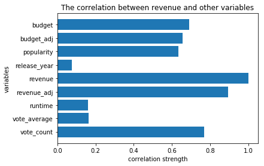

```python
plt.gca().invert_yaxis()
plt.barh(df_cor["revenue"].index ,df_cor["revenue"]);
plt.title("The correlation between revenue and other variables")
plt.xlabel("correlation strength")
plt.ylabel("variables")
```

As you can see, the most variables affecting revenue are: **budget , vote_count , popularity I prove this by mean and scatter In the following codes

```python
high_revenue= df[df["revenue"] >= df["revenue"].median()]
low_revenue= df[df["revenue"] < df["revenue"].median()]

print(f"compare in Budget {high_revenue['budget'].mean() , low_revenue['budget'].mean()}")
print(f"compare in vote count{high_revenue['vote_count'].mean() , low_revenue['vote_count'].mean()}")
print(f"compare in popularity{high_revenue['popularity'].mean() , low_revenue['popularity'].mean()}")
```

```
compare in Budget (17634121.97738764, 12045364.894347986)
compare in vote count(275.7957865168539, 139.18840044329517)
compare in popularity(0.7265778925561797, 0.6010659327669006)
```

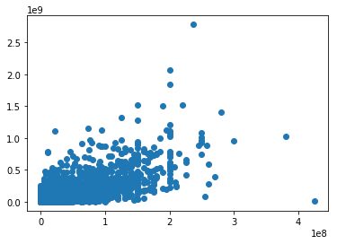

```python
#there is a positive correlation
plt.scatter(df['budget'],df['revenue'])
```

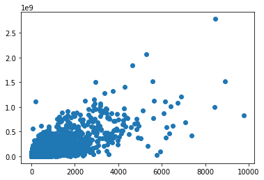

```python
#there is a positive correlation
plt.scatter(df['vote_count'],df['revenue'])
```

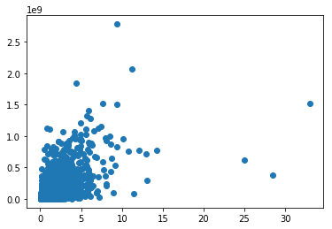

```python
#there is a positive correlation
plt.scatter(df['popularity'],df['revenue'])
```

### Research Question 2 (Which movie have high popularity over this years!)

```python
def high_movie_popularity(year1 = 0 , year2 = 0) :
    ''' this function will give us the most popular Movies
        Parameters :
        year1 : int b
               if you not give any number the function will give you insights of all years
               if you give a specific year the function will give you insights of this years
        year2 : int (year between year_1 to 2016)
                if you give a specific year the function will give you insights between year_1 and year_2
    '''
    sorted_popularity = df.sort_values(by ='popularity',ascending= False)
    if year2 == 0 :
        year2 = year1
    if year1 != 0 :
        sorted_popularity.query('release_year >= @year1 and release_year <= @year2',inplace = True)

    plt.subplots(figsize=(10,8))
    plt.gca().invert_yaxis()
    plt.barh(sorted_popularity['original_title'].head(10),sorted_popularity['popularity'].head(10))
```

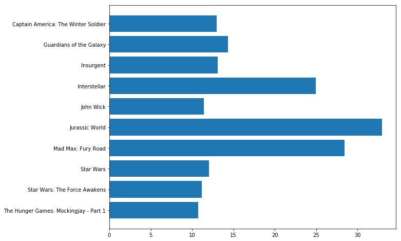

```python
high_movie_popularity()
```

**jurassic world**: movie have the most popularity all years

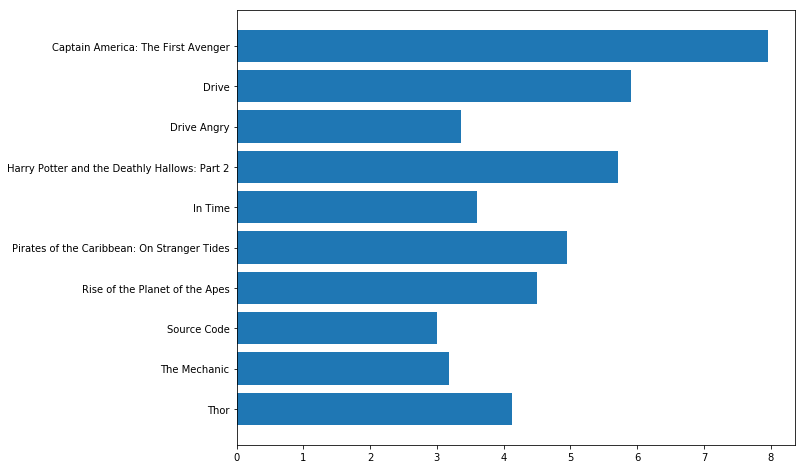

```python
high_movie_popularity(2011)
```

the most popular movie in "2011" is **Captin America: the first avenger**

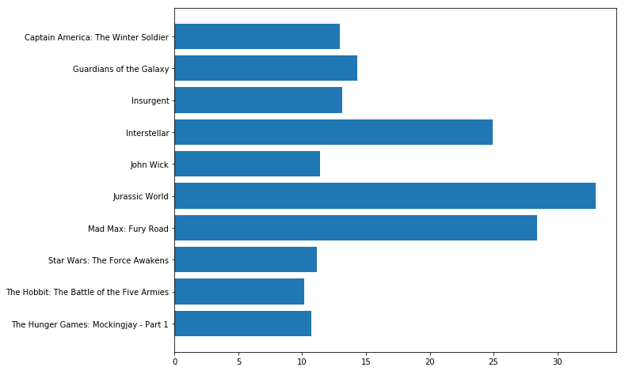

```python
high_movie_popularity(2000,2015)
```

the most popular movie from 2000 to 2015 is **jurassic world**

```python
df["genres"].head(1)
```

```
0    Action|Adventure|Science Fiction|Thriller
Name: genres, dtype: object
```

**The biggest problem in answering this question is that we need to separate genres from each other This is what we will do in the following lines**

```python
#Separated geners from each other by and store each value in seperate columns
genres_df = df['genres'].str.split("|", expand=True)
genres_df.head(3)
```

|  | 0 | 1 | 2 | 3 | 4 |
| --- | --- | --- | --- | --- | --- |
| 0 | Action | Adventure | Science Fiction | Thriller | None |
| 1 | Action | Adventure | Science Fiction | Thriller | None |
| 2 | Adventure | Science Fiction | Thriller | None | None |

```python
# Creating a separate dataframe form unique genres records.
genres_df = genres_df.stack()
genres_df = pd.DataFrame(genres_df)
genres_df.head()
```

|  |  | 0 |
| --- | --- | --- |
| 0 | 0 | Action |
|  | 1 | Adventure |
|  | 2 | Science Fiction |
|  | 3 | Thriller |
| 1 | 0 | Action |

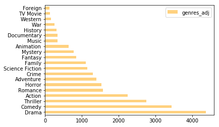

```python
genres_df.rename(columns={0:'genres_adj'}, inplace=True)
genres_df['genres_adj'].value_counts().plot(kind='barh',alpha=0.5, color= 'orange', label='genres_adj')
plt.legend();
```

### Conclusion

**there are a couple of limitations with our data:**

- There are many missing values in this data
- There are some wrong value in the data entered such as some values in 'runtime or relase_year' All these will lead either to wrong analysis which will lead to wrong predictions or biased analysis.
- There are some columns such as genres the values in them are connected by "|" and this makes it difficult to answer questions that depend on the comparison between these values

```python
from subprocess import call
call(['python', '-m', 'nbconvert', 'Investigate_a_Dataset.ipynb'])
```

```
0
```